# Relatorio 02 - GLM para dados discretos

Juliana A. Moureira

02-10-2025

## 1 Introdução

**O que são dados discretos:**

São dados que só podem assumir valores inteiros e contáveis.

Exemplo: número de corais em uma área, número de peixes capturados, número de erros em um experimento.  
**Características principais:**

- Não há valores “entre” (ex: não existe 2,5 corais).
- Normalmente representam contagens (0, 1, 2, 3…).
- A variabilidade dos dados aumenta junto com a média (coisa comum em contagens).  
  **Modelos adequados:**

Para esse tipo de dado, usamos modelos lineares generalizados (GLM) com distribuições específicas, como Poisson ou Binomial Negativa.

```r
library(MASS)    # glm.nb
library(ggplot2) # gráficos
library(gridExtra)
library(DHARMa)
```

```r
#~~~~~~~~~~~~~~~~~~~~~~~~~~~~~~~~
## 1. Importando o banco de dados
#~~~~~~~~~~~~~~~~~~~~~~~~~~~~~~~~
dados <- readRDS("../Dados/benthos_exposure.rds")
```

Esses dados mostram a riqueza de macrofauna bentônica registrada em diferentes praias. E aqui vamos explorar esses dados e associar a riqueza à fatores de exposição de estresse ambiental e altura em relação a maré.

```r
#~~~~~~~~~~~~~~~~~~~~~~~~~~
# 2. Explorando os dados
#~~~~~~~~~~~~~~~~~~~~~~~~~~
str(dados)
```

```
## 'data.frame':    45 obs. of  5 variables:
##  $ Sample  : int  1 2 3 4 5 6 7 8 9 10 ...
##  $ Richness: int  11 10 13 11 10 8 9 8 19 17 ...
##  $ Exposure: int  10 10 10 10 10 8 8 8 8 8 ...
##  $ NAP     : num  0.045 -1.036 -1.336 0.616 -0.684 ...
##  $ Beach   : int  1 1 1 1 1 2 2 2 2 2 ...
```

```r
View(dados)
```

Os dados são compostos pelos seguintes campos:

- **Sample:** número da amostra
- **Richness:** riqueza de macrofauna bentônica
- **Exposure:** índice de exposição (8, 10, 11)
- **NAP:** altura da estação de amostragem em relação à maré
- **Beach:** Praia em que foi feito a amostragem

```r
#~~~~~~~~~~~~~~~~~~~~~~~~~~
# 2.1. Transformando as variáveis
#~~~~~~~~~~~~~~~~~~~~~~~~~~
## int -> vector
## Richness, Exposure e NAP → numéricas (contínuas)
dados[, c("Richness", "Exposure", "NAP")] <- lapply(dados[, c("Richness", "Exposure", "NAP")], as.numeric)

## Sample e Beach → fatores (identificação e categoria)
dados[, c("Sample", "Beach")] <- lapply(
  dados[, c("Sample", "Beach")],
  as.factor)

## Conferindo as classes finais
str(dados)
```

```
## 'data.frame':    45 obs. of  5 variables:
##  $ Sample  : Factor w/ 45 levels "1","2","3","4",..: 1 2 3 4 5 6 7 8 9 10 ...
##  $ Richness: num  11 10 13 11 10 8 9 8 19 17 ...
##  $ Exposure: num  10 10 10 10 10 8 8 8 8 8 ...
##  $ NAP     : num  0.045 -1.036 -1.336 0.616 -0.684 ...
##  $ Beach   : Factor w/ 9 levels "1","2","3","4",..: 1 1 1 1 1 2 2 2 2 2 ...
```

### 1.1 Analisando as métricas

A coluna’Richness’ traz informação sobre a riqueza da macrofauna bentônica nos locais amostrados. Já a coluna ‘Exposure’mostra o índice de exposição, enquanto a coluna ’NAP’ mostra a altura da estação de amostragem em relação à maré. Abaixo vamos explorar gráficos levando em consideração essas 3 variáveis.

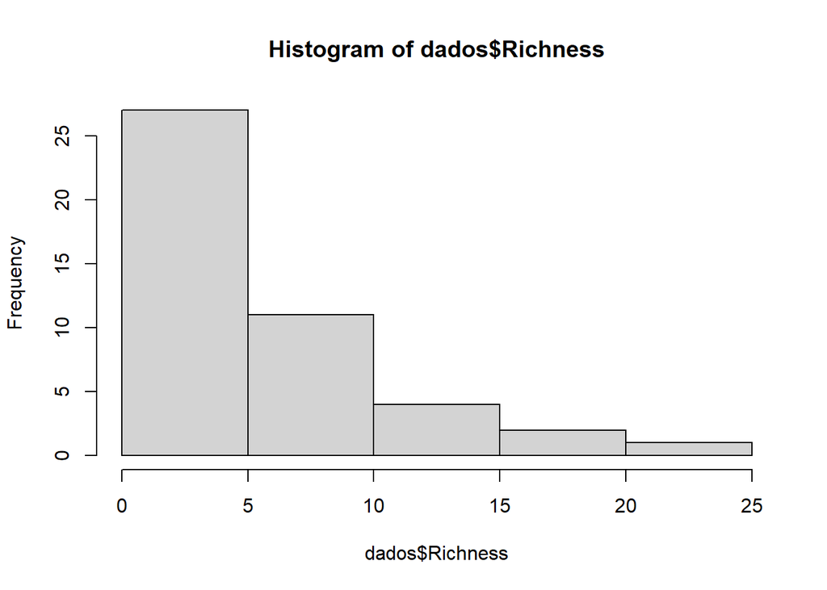

```r
#~~~~~~~~~~~~~~~~~~~~~~~~~~
# 2.2) Visualizando dados
#~~~~~~~~~~~~~~~~~~~~~~~~~~
library(ggplot2)
library(gridExtra)
library(performance)

## Distribuição dos dados (variável y)
hist(dados$Richness)
```

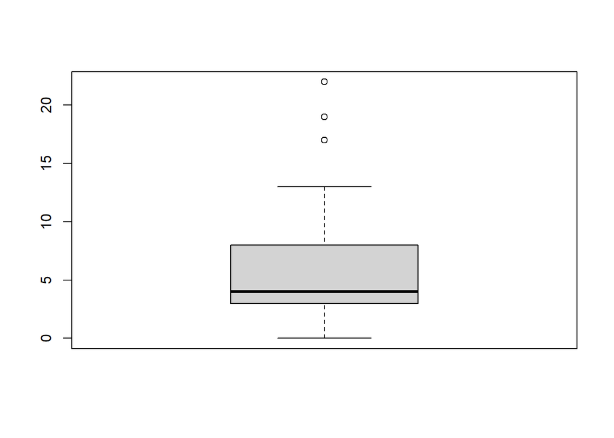

```r
boxplot(dados$Richness)
```

```r
summary(dados$Richness)
```

```
##    Min. 1st Qu.  Median    Mean 3rd Qu.    Max.
##   0.000   3.000   4.000   5.689   8.000  22.000
```

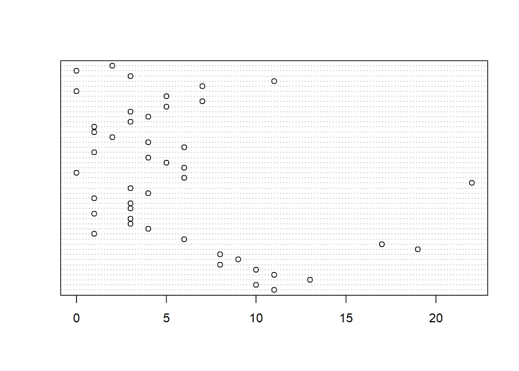

```r
dotchart(dados$Richness)
```

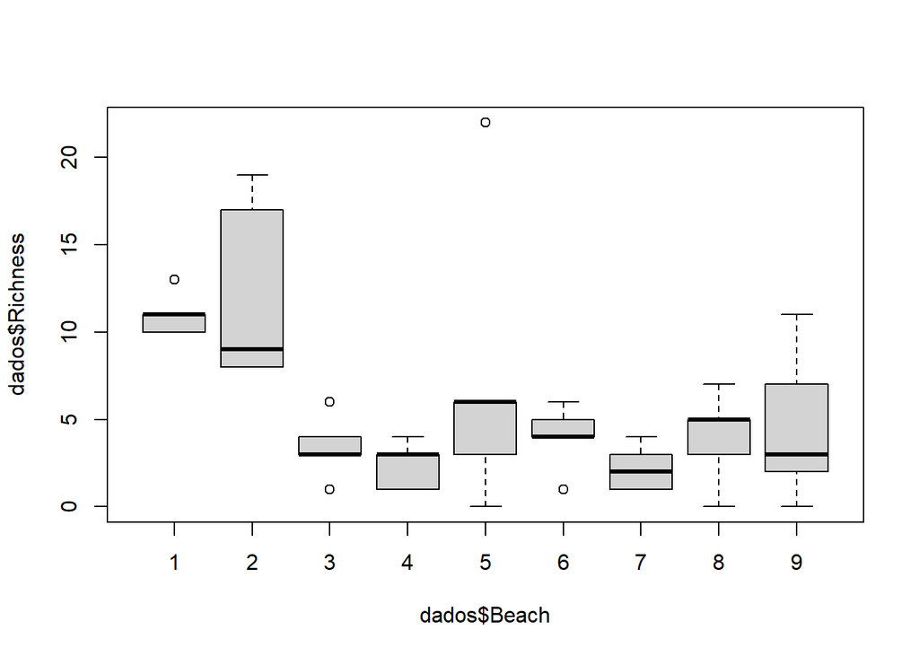

```r
## Dinâmica espacial - riqueza por localidade
plot(dados$Richness ~ dados$Beach)
```

## 2 Modelando a riqueza

**Distribuição poisson**

**Quando usar:** Quando estamos modelando contagens de eventos raros, onde:

- Os eventos são independentes entre si.
- A média de ocorrências é constante no tempo ou espaço.

**Características:** - A variável resposta é um número inteiro ≥ 0. - A média (λ, lambda) representa tanto a média quanto a variância da distribuição.

- Ou seja: Var(Y) = E(Y) = λ

No GLM, usamos a função de ligação logarítmica:

```
         log(λ)=β0+β1x1+⋯+βnxn
```

```r
#~~~~~~~~~~~~~~~~~~~~~~~~~~~~~~~~~~~~~~~~~~~~~~
# 3) Modelos GLM Poisson e Binominal Negativa e análise de resíduos + correlação ambiental
#~~~~~~~~~~~~~~~~~~~~~~~~~~~~~~~~~~~~~~~~~~~~~~

#~~~~~~~~~~~~~~~~~~~~~~~~~~~~
# 3.1) Distribuição poisson
#~~~~~~~~~~~~~~~~~~~~~~~~~~~~
mod_poisson <- glm(Richness ~ Exposure + NAP,
                   data = dados,
                   family = poisson(link = "log"))

summary(mod_poisson)
```

```
##
## Call:
## glm(formula = Richness ~ Exposure + NAP, family = poisson(link = "log"),
##     data = dados)
##
## Coefficients:
##             Estimate Std. Error z value Pr(>|z|)
## (Intercept)  5.92874    0.54660  10.847  < 2e-16 ***
## Exposure    -0.41366    0.05558  -7.443 9.84e-14 ***
## NAP         -0.52187    0.06924  -7.537 4.80e-14 ***
## ---
## Signif. codes:  0 '***' 0.001 '**' 0.01 '*' 0.05 '.' 0.1 ' ' 1
##
## (Dispersion parameter for poisson family taken to be 1)
##
##     Null deviance: 179.753  on 44  degrees of freedom
## Residual deviance:  63.735  on 42  degrees of freedom
## AIC: 211.73
##
## Number of Fisher Scoring iterations: 5
```

```r
#~~~~~~~~~~~~~~~~~~~~~~~~~~~~
# 3.2) Sobredispersão
#~~~~~~~~~~~~~~~~~~~~~~~~~~~~
phi <- mod_poisson$deviance / mod_poisson$df.residual
phi
```

```
## [1] 1.517509
```

```r
cat("Phi (sobredispersão) =", phi, "\n")
```

```
## Phi (sobredispersão) = 1.517509
```

```r
phi  # phi >> 1 indica sobredispersão
```

```
## [1] 1.517509
```

Com o ajuste do modelo Poisson, vimos que os parametros ‘exposição’ e ‘NAP’ são significativos em relação a riqueza.

**Distribuição Binomial Negativa**

**Quando usar:** É uma extensão da Poisson para lidar com superdispersão — ou seja, quando a variância é maior que a média.

**Características:** - Ainda modela dados de contagem. - Introduz um parâmetro extra (k) que controla a dispersão:

[output not shown]

- Se 𝑘→∞, o modelo vira uma Poisson.
- Também usa a função de ligação logarítmica:

  ```
                log(μ)=β0+β1x1+⋯+βnxn
  ```

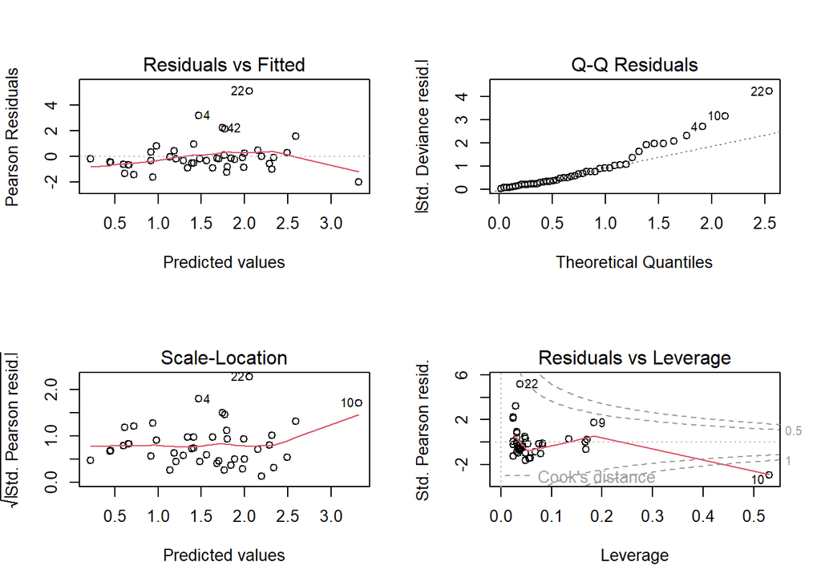

```r
## Rápida inspecção residual
par(mfrow=c(2,2))
plot(mod_poisson)
```

```r
par(mfrow=c(1,1))

check_overdispersion(mod_poisson)
```

```
## # Overdispersion test
##
##        dispersion ratio =  1.651
##   Pearson's Chi-Squared = 69.354
##                 p-value =  0.005
```

```r
#~~~~~~~~~~~~~~~~~~~~~~~~~~~~
# 3.3) Ajustando modelo Binomial Negativa
#~~~~~~~~~~~~~~~~~~~~~~~~~~~~
mod_nb <- glm.nb(Richness ~ Exposure + NAP, data = dados)
summary(mod_nb)
```

```
##
## Call:
## glm.nb(formula = Richness ~ Exposure + NAP, data = dados, init.theta = 11.79086055,
##     link = log)
##
## Coefficients:
##             Estimate Std. Error z value Pr(>|z|)
## (Intercept)  6.38793    0.76099   8.394  < 2e-16 ***
## Exposure    -0.45921    0.07616  -6.029 1.65e-09 ***
## NAP         -0.59253    0.08962  -6.612 3.80e-11 ***
## ---
## Signif. codes:  0 '***' 0.001 '**' 0.01 '*' 0.05 '.' 0.1 ' ' 1
##
## (Dispersion parameter for Negative Binomial(11.7909) family taken to be 1)
##
##     Null deviance: 122.286  on 44  degrees of freedom
## Residual deviance:  40.496  on 42  degrees of freedom
## AIC: 206.84
##
## Number of Fisher Scoring iterations: 1
##
##
##               Theta:  11.79
##           Std. Err.:  6.48
##
##  2 x log-likelihood:  -198.844
```

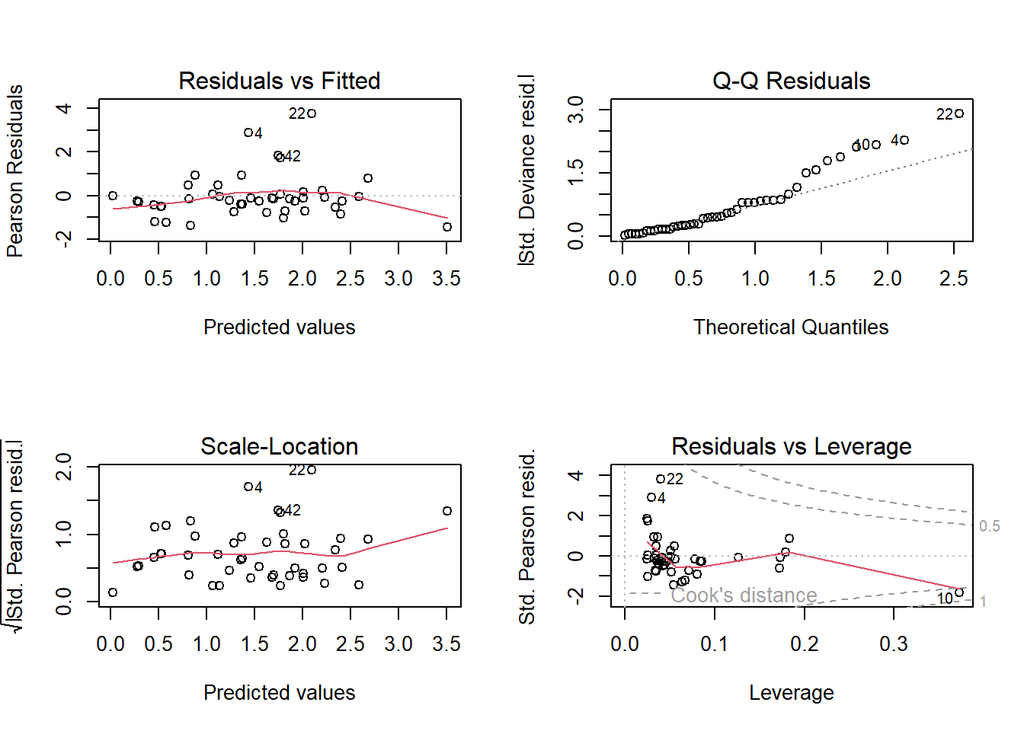

```r
## Rápida inspecção residual
par(mfrow=c(2,2))
plot(mod_nb)
```

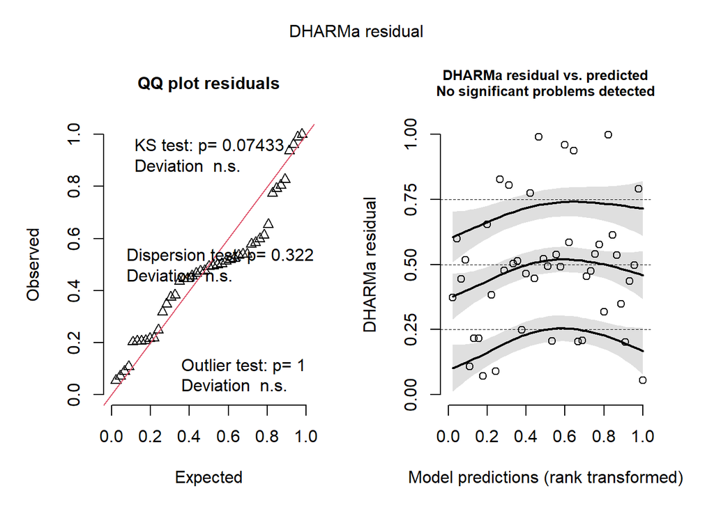

```r
par(mfrow=c(1,1))


simres2 <- simulateResiduals(mod_nb, n=1000)
plot(simres2)
```

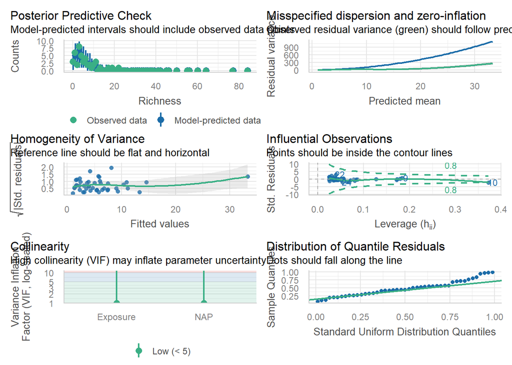

```r
check_model(mod_nb)
```

```r
check_zeroinflation(mod_nb)
```

```
## # Check for zero-inflation
##
##    Observed zeros: 3
##   Predicted zeros: 3
##             Ratio: 1.02
```

Com o modelo Binomial Negativa, também foi possível verificar que houve significância entre os parametros ‘exposição’ e ’NAP’em relação a riqueza.

```r
#~~~~~~~~~~~~~~~~~~~~~~~~~~~~
# 3.4) Comparação via AIC
#~~~~~~~~~~~~~~~~~~~~~~~~~~~~
aic_table <- data.frame(
  Modelo = c("Poisson", "Binomial Negativa"),
  AIC = c(AIC(mod_poisson), AIC(mod_nb))
)
aic_table
```

```
##              Modelo      AIC
## 1           Poisson 211.7338
## 2 Binomial Negativa 206.8440
```

Agora quando comparamos a AIC dos modelos, o modelo Binomial Negativa possui menor AIC, sendo assim o melhor ajuste para os dados.